# Efficient R Ch: 1-3

### Chapters 1-3

Notes from *Efficient R Programming* by Colin Gillespie & Robin Lovelace

#### Benchmarking

We can use the function microbenchmark() to compare snippets of code that perform the same exact task but at different speeds.

```r
library(microbenchmark)
df = data.frame(v = 1:4, name = letters[1:4])

(df[3,2] == df[3,"name"]) == (df$name[3]==df[3,2])
```

```
## [1] TRUE
```

```r
microbenchmark(df[3,2], df[3,"name"], df$name[3])
```

```
## Unit: microseconds
##           expr    min      lq     mean  median      uq     max neval
##       df[3, 2] 13.969 16.0380 19.75699 17.1050 18.6200 135.872   100
##  df[3, "name"] 14.757 16.2070 18.08856 16.9550 18.0765  40.456   100
##     df$name[3] 10.262 11.9685 13.54147 12.8095 13.8560  29.310   100
```

We can see here that the most efficient way of pulling an object out of a dataframe is with code of the structure df$name[n]. Though, consider the fact that this is on the order or microseconds and when you have functions that take seconds to run, skimming time this way might be inefficient.

#### Benchmarking: Example 2, cumulative sum

```r
x = 1:100

# Method 1: For loop
cs_for = function(x) {
     for(i in x) {
          if(i == 1) {
               xc = x[i]
          } else {
               xc = c(xc, sum(x[1:i]))
          }
     }
     xc
}

# Method 2: with apply

cs_apply = function(x) {
     sapply(x, function(x) sum(1:x))
}

# Method 3: cumsum()
cumsum(x)
```

```
##   [1]    1    3    6   10   15   21   28   36   45   55   66   78   91  105
##  [15]  120  136  153  171  190  210  231  253  276  300  325  351  378  406
##  [29]  435  465  496  528  561  595  630  666  703  741  780  820  861  903
##  [43]  946  990 1035 1081 1128 1176 1225 1275 1326 1378 1431 1485 1540 1596
##  [57] 1653 1711 1770 1830 1891 1953 2016 2080 2145 2211 2278 2346 2415 2485
##  [71] 2556 2628 2701 2775 2850 2926 3003 3081 3160 3240 3321 3403 3486 3570
##  [85] 3655 3741 3828 3916 4005 4095 4186 4278 4371 4465 4560 4656 4753 4851
##  [99] 4950 5050
```

```r
microbenchmark(cs_for(x), cs_apply(x), cumsum(x))
```

```
## Unit: nanoseconds
##         expr    min       lq      mean   median       uq     max neval
##    cs_for(x) 164874 176981.0 236864.75 200674.5 215208.5 2052143   100
##  cs_apply(x) 103522 110448.0 126217.10 124250.5 134312.0  234801   100
##    cumsum(x)    454    516.5    781.42    633.5    701.5   11020   100
```

Clearly, the base function cumsum() is the preferred method of the three presented. Generally speaking, if there is a base function available for the task at hand, use it. Don’t reinvent the wheel.

#### Profiling

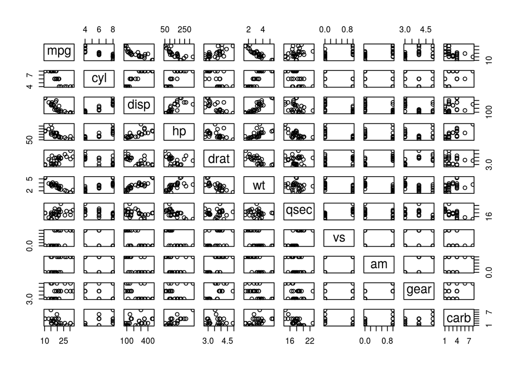

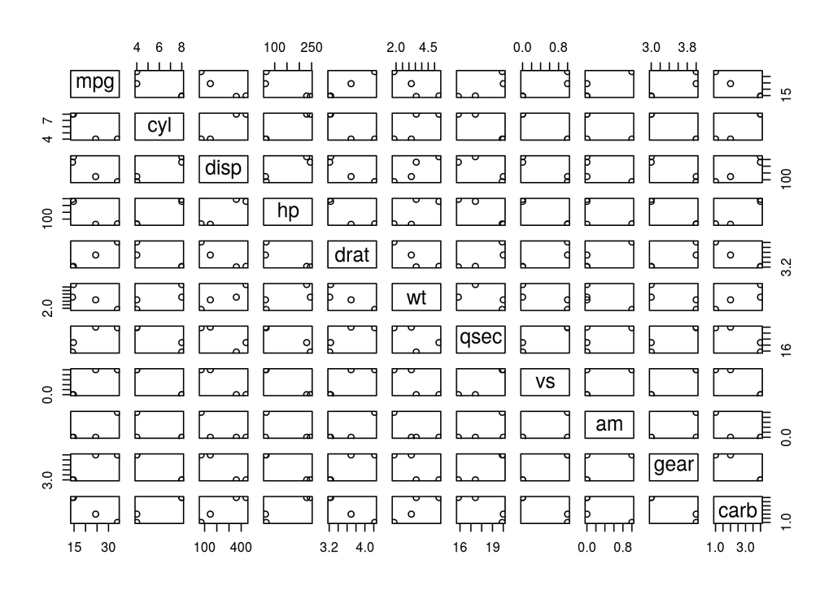

[interactive chart not shown]

```r
library(profvis)

profvis({

    theData = mtcars
    proportion = .9

    # The following code is from the sampler() function in the fdRen package.
    samplesTrain <- sample(1:nrow(theData), size = trunc(nrow(theData) *
        proportion), replace = FALSE)
    train <- theData[samplesTrain, ]
    test <- theData[-samplesTrain, ]
    returnList <- list()
    returnList[["train"]] <- train
    returnList[["test"]] <- test
    returnList
    ###


    plot(returnList$train)
    plot(returnList$test)

})
```

We can see here that it takes the longest amount of time to plot the graph and everything else is a minimal amount of time. However, you will need to run this code in your own R session in order to see the results. This is because the profvis output opens in a new window and not through the R console.

#### Efficient Setup:

First, it helps to be able to monitor your system to see what is going on. On Linux, you can use htop or gnome-system-monitor in the bash shell. Mac, use Activity Monitor. Windows, use Task manager.

Some functions, like lapply, have parallel versions. *Open your cpu manager and observe the following chunks of code separately*.

```r
# Note, uses 2+ GB RAM and takes several seconds depending on hardware
# 1: Create large dataset
X = as.data.frame(matrix(rnorm(1e8), nrow = 1e7))
```

```r
t1 = Sys.time()
r1 = lapply(X, median)
t2 = Sys.time()
t2-t1
```

```
## Time difference of 5.078032 secs
```

```r
# parallel mclapply
t1 = Sys.time()
r2 = parallel::mclapply(X, median)
t2 = Sys.time()
t2-t1
```

```
## Time difference of 3.344451 secs
```

#### .Rprofile

To have a chunk of code run each time R is loaded, edit the .Rprofile file.

```
file.edit("~/.Rprofile") # edit .Rprofile in HOME
file.edit(".Rprofile")   # edit project-specific .Rprofile
```

Any project-specific functions/code will be loaded *after* anything in the HOME environment. Remember R’s loading preference for future reference.

##### My current .Rprofile, created by running

```
# in bash
vim ~/.Rprofile
```

The .Rprofile file has the following code

```
message("Have a great day!")
# Customize the R prompt that prefixes every command
options(prompt = " ")
options(continue = " ")
# Load the fortunes package for fun
if(interactive())
    try(fortunes::fortune(), silent = TRUE)
.Last = function() {
message("Goodbye at ", date(), "\n")
}
# Creating a hidden environment
.env = new.env()
.env$ht = function(d, n = 6) rbind(head(d, n), tail(d, n))
```

```r
# To run the hidden environment function ht as seen in the .Rprofile code above
attach(.env)

# Return top two and bottom two results
ht(mtcars, 2)
```

```
##                mpg cyl disp  hp drat    wt  qsec vs am gear carb
## Mazda RX4     21.0   6  160 110 3.90 2.620 16.46  0  1    4    4
## Mazda RX4 Wag 21.0   6  160 110 3.90 2.875 17.02  0  1    4    4
## Maserati Bora 15.0   8  301 335 3.54 3.570 14.60  0  1    5    8
## Volvo 142E    21.4   4  121 109 4.11 2.780 18.60  1  1    4    2
```

#### Organizing projects

You should have the following file structure

```
project/
  - README.Rmd # Project Documentation
  - set-up.R   # Required Packages
  - R/         # for R code
  - input      # data files
  - graphics/
  - output/    # Results
```

#### Installing BLAS (Basic Linear Algebra System)

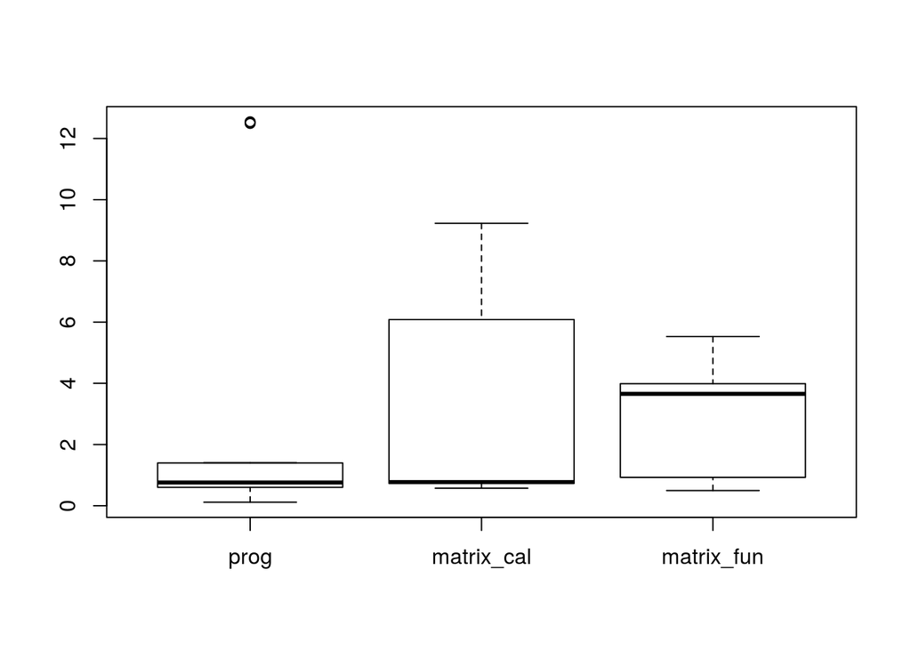

```r
library(benchmarkme)
# get_linear_algebra()
# res = benchmark_std()
# saveRDS(res, "res.Rda")
res1 = readRDS("res.Rda")
plot(as.factor(res1[,5]), res1[,1])
```

##### For Test 1

```
# Programming benchmarks (5 tests):
    3,500,000 Fibonacci numbers calculation (vector calc): 0.615 (sec).
    Grand common divisors of 1,000,000 pairs (recursion): 0.824 (sec).
    Creation of a 3500x3500 Hilbert matrix (matrix calc): 0.142 (sec).
    Creation of a 3000x3000 Toeplitz matrix (loops): 12.5 (sec).
    Escoufier's method on a 60x60 matrix (mixed): 1.43 (sec).
# Matrix calculation benchmarks (5 tests):
    Creation, transp., deformation of a 5000x5000 matrix: 0.741 (sec).
    2500x2500 normal distributed random matrix ^1000: 0.574 (sec).
    Sorting of 7,000,000 random values: 0.773 (sec).
    2500x2500 cross-product matrix (b = a' * a): 9.16 (sec).
    Linear regr. over a 3000x3000 matrix (c = a \ b'): 6.08 (sec).
# Matrix function benchmarks (5 tests):
    Cholesky decomposition of a 3000x3000 matrix: 5.11 (sec).
    Determinant of a 2500x2500 random matrix: 3.94 (sec).
    Eigenvalues of a 640x640 random matrix: 0.935 (sec).
    FFT over 2,500,000 random values: 0.499 (sec).
    Inverse of a 1600x1600 random matrix: 3.66 (sec).
```

##### Top 5 Tips for Efficient Programming

1. Be careful never to grow vectors
2. Vectorize code whenever possible
3. Use factors when appropriate
4. Avoid unnecessary computation by caching variables
5. Byte compile packages for an easy performance boost

See [this link](https://en.wikipedia.org/wiki/Optimizing_compiler) for an overview of standard optimizaiton techniques.

See “The R Inferno” by Patric Burns (Lulu.com)

##### What’s Under the Hood / General Advice

Ultimately, calling an R function always ends up calling some underlying C/Fortran code. For example, the base R function runif() only contains a single line that consists of a call to C_runif().

```
function (n, min = 0, max = 1)
 .Call(C_runif, n, min, max)
```

The rule in R programming is to access the underlying C/Fortran routines as quickly as possible; the fewer function calls required to achieve this, the better. For example, suppose $x$ is a standard vector of length $n$. Then

```
x = x + 1
```

involves a sungle function call to the + function. Whereas the `for` loop

```
for(i in seq_len(n))
    x[i] = x[i] + 1
```

has

- $n$ funtion calls to +
- $n$ function calls to the [ function
- $n$ function calls to the [<- function (used in assignment operation)
- A function call to `for and to the : operator

It isn’t that the `for` loop is slow; rather it is because we have many more function calls. Each individual function call is quick, but the total combination is slow.

*Everything in R is a function call. When we execute 1+1, we are actually executing +(1, 1)*

Let’s use the `library(microbenchmark)` package to compare the vectorized construct `x = x + 1`.

```r
n = 50
x = seq(1:n)
library(microbenchmark)
microbenchmark(x + 1, # first
               for(i in seq_len(n)) { # second
                    x[i] = x[i] + 1
                    })
```

```
## Unit: nanoseconds
##                                           expr   min      lq     mean
##                                          x + 1   224   335.0   529.35
##  for (i in seq_len(n)) {     x[i] = x[i] + 1 } 47607 57498.5 63862.35
##  median    uq   max neval
##     428   538  7564   100
##   61797 71488 92079   100
```

#### Memory Allocation

If possible, pre-allocate your vector and then fill in the values. *You should consider preallocating memory for data frames and lists. Never grow and object. A good rule of thumb is to compare your objects before and after a `for` loop; have they increases in length?

Let’s look at two different methods of creating a sequence of numbers.

```r
library(microbenchmark)

# Unvectorized Code
method1 = function(n) {
     vec = NULL # Or vec = c()
     for(i in seq_len(n)) {
          vec = c(vec, i)
     }
     vec
}

# Vectorized Code
method2 = function(n) {
     vec = numeric(n)
     for(i in seq_len(n)) {
          vec[i] = i
     }
     vec
}

# Base function
method3 = function(n) seq_len(n)

n = 10e4
microbenchmark(times = 1, unit = "s", method1(n), method2(n), method3(n))
```

```
## Unit: seconds
##        expr          min           lq         mean       median
##  method1(n) 11.165545302 11.165545302 11.165545302 11.165545302
##  method2(n)  0.080509173  0.080509173  0.080509173  0.080509173
##  method3(n)  0.000142618  0.000142618  0.000142618  0.000142618
##            uq          max neval
##  11.165545302 11.165545302     1
##   0.080509173  0.080509173     1
##   0.000142618  0.000142618     1
```

```r
# Clearly, method 3 and method 2 are much faster.


# Out of my own curiosity, I decided to see the difference in speed between seq and seq_len
microbenchmark(seq(1:10), seq_len(10))
```

```
## Unit: nanoseconds
##         expr  min     lq    mean median     uq   max neval
##    seq(1:10) 3132 3506.0 5268.14   3825 4116.0 57623   100
##  seq_len(10)   79   89.5  136.88     97  141.5  1790   100
```

Looking a little more at vectorized functions, consider this piece of R code that calculates the sum of log(x):

```
log_sum = 0
for(i in 1:length(x))
 log_sum = log_sum + log(x[i])
```

*Note: using 1:length(x) can lead to hard-to-find bugs when x has length zer. Instead, use seq_along(x) or seq_len(length(x))*

This code could easily vectorized via `log_sum = sum(log(x))`.

Writing code this way has benefits:

- It’s faster. When n = 10<sup>7</sup> the R *way* is about 40 times faster.
- It’s neater
- It doesn’t contain a bug when x is of length 0

Another example: Monte Carlo Simulation

We need to make use of functions that use R vectors as much as possible. For example, suppose we want to evaluate the function $\int_0^1{x^2}\;dx$ using a Monte Carlo method.

```r
# A typical way to run the Mente Carlo simulation

monte_carlo = function(N) {
     hits = 0
     for(i in seq_len(N)) {
          u1 = runif(1)
          u2 = runif(1)
          if(u1 ^ 2 > u2)
               hits = hits + 1
     }
     return(hits / N)
}

# In R, this takes a few seconds
N = 500000
cat("For typical code\n")
```

```
## For typical code
```

```r
system.time(monte_carlo(N))
```

```
##    user  system elapsed
##   1.872   0.036   1.905
```

```r
# IN CONTRAST, a more R centric approach would be:
monte_carlo_vec = function(N) {
     mean(runif(N)^2 > runif(N))
}
cat("For vectorized code\n")
```

```
## For vectorized code
```

```r
system.time(monte_carlo_vec(N))
```

```
##    user  system elapsed
##   0.036   0.000   0.039
```

The `monte_carlo_vec()` function contains at least four aspects of vectorization:

- The runif() function call is now fully vectorized.
- We raise entire vectors to a power via ^
- Comparisons using > are vectorized
- Using mean() is quicker than an equivalent for loop

#### Communicating with the User

Fatal Errors: `stop()` When `stop()` is called, there is no way for a function to continue. Errors can be caught using `try()` and `tryCatch()` Warnings are generated using the `warning()` function. Warnings can be suppressed using the `suppressWarnings()` function. To give informative output, use the `message()` function. Similar to warnings, the `suppressMessages()` function can be used to stop messages. The `invisible()` function allows you to return a temporarily invisible copy of an object.

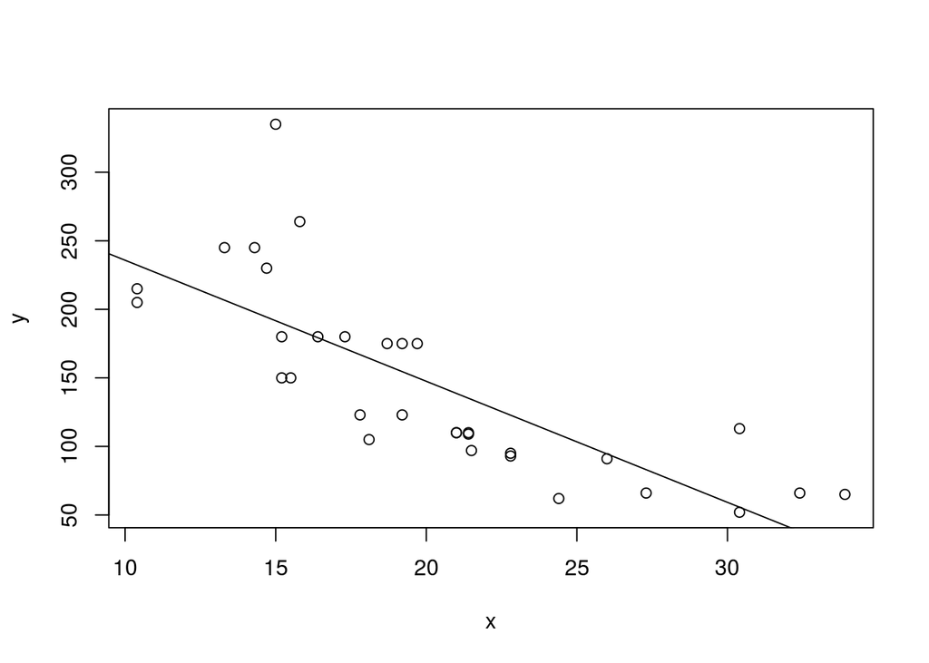

```r
regression_plot = function(x, y, ...) {
     # Plot an pass additional arguments to default plot method
     plot(x, y, ...)

     # Fit regression model
     model = lm(y ~ x)

     # Add line of best fit to the plot
     abline(model)
     invisible(model)
}

reg_plot = regression_plot(mtcars$mpg, mtcars$hp)
```

```r
names(reg_plot)
```

```
##  [1] "coefficients"  "residuals"     "effects"       "rank"
##  [5] "fitted.values" "assign"        "qr"            "df.residual"
##  [9] "xlevels"       "call"          "terms"         "model"
```

```r
reg_plot
```

```
##
## Call:
## lm(formula = y ~ x)
##
## Coefficients:
## (Intercept)            x
##      324.08        -8.83
```

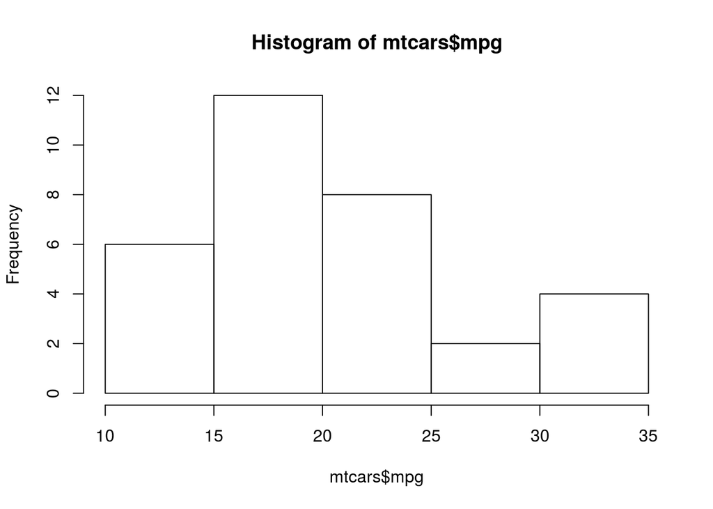

```r
# As another example of the invisible() function, assign the hist() function to an object.
myHist = hist(mtcars$mpg) # histogram shows but output does not
```

```r
names(myHist)
```

```
## [1] "breaks"   "counts"   "density"  "mids"     "xname"    "equidist"
```

```r
myHist
```

```
## $breaks
## [1] 10 15 20 25 30 35
##
## $counts
## [1]  6 12  8  2  4
##
## $density
## [1] 0.0375 0.0750 0.0500 0.0125 0.0250
##
## $mids
## [1] 12.5 17.5 22.5 27.5 32.5
##
## $xname
## [1] "mtcars$mpg"
##
## $equidist
## [1] TRUE
##
## attr(,"class")
## [1] "histogram"
```

#### Factors

A factor is used to store categorical variables. The difference between factors and strings is that factors are stored as integers.

```r
x = 4:6
c(x)
```

```
## [1] 4 5 6
```

```r
c(factor(x))
```

```
## [1] 1 2 3
```

In this case, the c() function is using the underlying int representation of the factor. This is a source of inefficiency for R.

As a general rule, if your variable has an inherent order (e.g., small versus large) or you have a fixed set of categories, then you should consider using a factor.

Inherent Order:

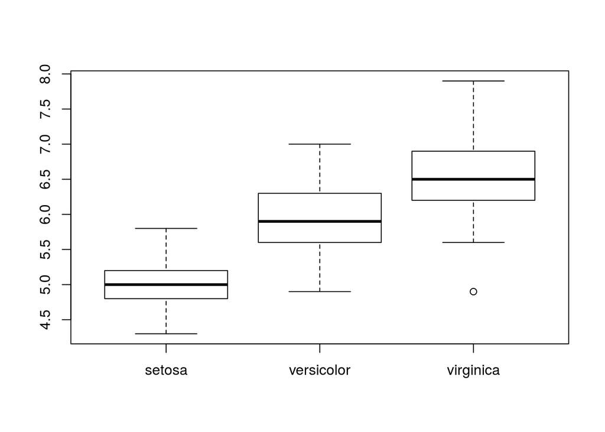

```r
# There isn't really an inherent order to the factors in this dataset, however if we wanted an order to the factors, we can use levels = c("Small", "Medium", "Large") or whatever the factors are. In this case, virginica, versicolor, and setosa.

boxplot(iris$Sepal.Length ~ iris$Species)
```

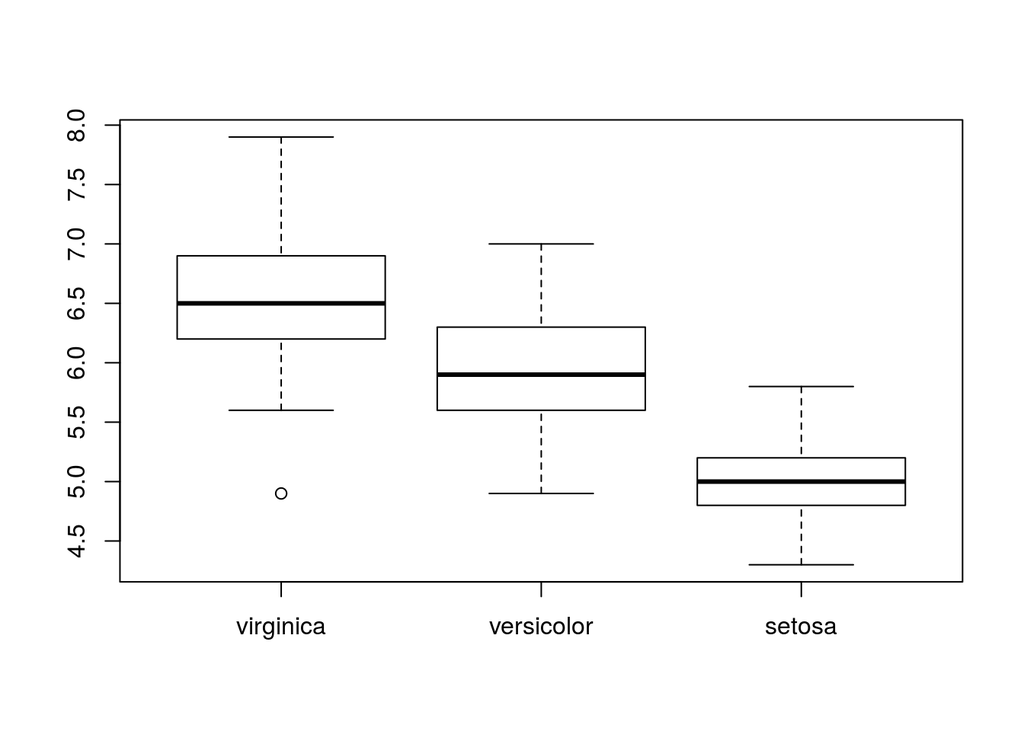

```r
boxplot(iris$Sepal.Length ~ factor(iris$Species, levels = c("virginica", "versicolor", "setosa")))
```

*Note: Generally speaking, we deal with factors when running the `read.csv()` function. Settings `stringsAsFactors = FALSE` initially allows one to manipulate/clean the dataset first and then convert columns into factors as needed.*

Fixed Set of Categories

Suppose out dataset relates to months of the year:

```r
m = c("January", "December", "March")

# If we use sort, this is the result we get
sort(m)
```

```
## [1] "December" "January"  "March"
```

We can use factors to remedy this problem by specifying the admissible levels:

```r
# month.name contains the 12 months
fac_m = factor(m, levels = month.name)
sort(fac_m)
```

```
## [1] January  March    December
## 12 Levels: January February March April May June July August ... December
```

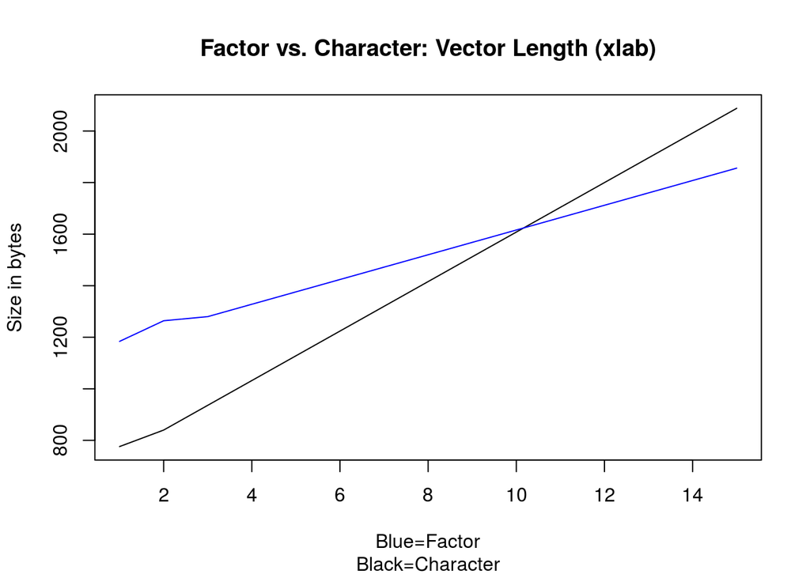

```r
charFacPlot <- function(n) {
     df = data.frame(n = seq_len(n), char = rep(NA, n), fac = rep(NA, n))
     for(i in seq_len(n)) {
         df$char[i] = pryr::object_size(rep(month.name, i))
         df$fac[i]  = pryr::object_size(as.factor(rep(month.name, i)))
     }
     plot(df$n, df$char, type = "l", ylab = "Size in bytes", xlab = "",
          main = "Factor vs. Character: Vector Length (xlab)", sub = "\nBlue=Factor\nBlack=Character")
     points(df$n, df$fac, col = "blue", type = "l")
}

charFacPlot(15)
```

#### The Apply Family

The apply functions can be used as alternatives to writing loops. The general idea is to apply (or map) a function to each element of an object. For example, you can apply a function to each row or column of a matrix.

- Each function takes at least two arguments: an object and another function.
- Every apply function allows arguments to be passed to the function provided in the FUN arguments.

```r
sapply(list((1:3)^2, 2:7), mean, trim = 0.4) # trim is an Argument used in the mean() function.
```

```
## [1] 4.0 4.5
```

The apply family of functions from base R

| Function | Description |
| --- | --- |
| apply | Apply functions over array margins |
| by | Apply a function to a data frame split by vectors |
| eapply | Apply a function over values in an environment |
| lapply | Apply a function over a list or vector |
| mapply | Apply a function to multiple list or vector arguments |
| rapply | Recursively apply a function to a list |
| tapply | Apply a function over a ragged array |

The apply() function is used to apply a function to each row or column of a matrix. For example, to calculate the standard deviation of each column in `mtcars`:

```r
apply(mtcars, 2, sd)
```

```
##         mpg         cyl        disp          hp        drat          wt
##   6.0269481   1.7859216 123.9386938  68.5628685   0.5346787   0.9784574
##        qsec          vs          am        gear        carb
##   1.7869432   0.5040161   0.4989909   0.7378041   1.6152000
```

Additional arguments can be passed to the function that is to be applied to the data. For example, pass the na.rm argument to the `sd()` function:

`apply()`

```r
data("ex_mat", package = "efficient")
# MARGIN = 1 corresponds to row, MARGIN = 2 corresponds to columns
row_sd = apply(ex_mat, MARGIN = 1, sd, na.rm = TRUE)
row_sd
```

```
##    [1] 0.3035667 0.2780355 0.2851506 0.2862142 0.3045457 0.2795286
##    [7] 0.2985008 0.3011121 0.2655497 0.2969071 0.3053163 0.2769979
##   [13] 0.3067830 0.2896472 0.2907540 0.2732683 0.3125168 0.2870153
##   [19] 0.3018761 0.2886948 0.2923708 0.2870956 0.2807771 0.2932752
##   [25] 0.2726272 0.3108141 0.2570290 0.2766728 0.2940460 0.2823327
##   [31] 0.2617460 0.2937360 0.2773780 0.2748584 0.2900869 0.3111661
##   [37] 0.2771202 0.3030389 0.2860034 0.2925570 0.2940338 0.2871123
##   [43] 0.3138672 0.2641358 0.2772682 0.3023504 0.3021753 0.2597542
##   [49] 0.2537788 0.2743966 0.2918899 0.2930640 0.2886387 0.3072290
##   [55] 0.2962587 0.2933022 0.2674364 0.3052778 0.2743638 0.2889175
##   [61] 0.2923693 0.2786753 0.3000713 0.2914012 0.2830759 0.2902147
##   [67] 0.2799991 0.2709352 0.2979544 0.3010187 0.2797082 0.3073320
##   [73] 0.2615263 0.2706261 0.2980109 0.2786313 0.2938846 0.2862919
##   [79] 0.3053485 0.2966374 0.2928937 0.2795087 0.2860823 0.2817833
##   [85] 0.2647286 0.3044148 0.2946182 0.2768445 0.2762458 0.3005474
```

[output cut: 152 more lines]

```r
# The lapply() function is similar to apply(). The main differences are that the input types are vectors or lists and the return type is a list. Essentially, we apply a function to each element of a list or vector.

x <- list(a = 1:10, beta = exp(-3:3), logic = c(TRUE,FALSE,FALSE,TRUE))
x
```

```
## $a
##  [1]  1  2  3  4  5  6  7  8  9 10
##
## $beta
## [1]  0.04978707  0.13533528  0.36787944  1.00000000  2.71828183  7.38905610
## [7] 20.08553692
##
## $logic
## [1]  TRUE FALSE FALSE  TRUE
```

```r
# compute the list mean for each list element
lapply(x, mean)
```

```
## $a
## [1] 5.5
##
## $beta
## [1] 4.535125
##
## $logic
## [1] 0.5
```

Additional example:

```r
data(movies, package = "ggplot2movies")
str(movies)
```

```
## Classes 'tbl_df', 'tbl' and 'data.frame':    58788 obs. of  24 variables:
##  $ title      : chr  "$" "$1000 a Touchdown" "$21 a Day Once a Month" "$40,000" ...
##  $ year       : int  1971 1939 1941 1996 1975 2000 2002 2002 1987 1917 ...
##  $ length     : int  121 71 7 70 71 91 93 25 97 61 ...
##  $ budget     : int  NA NA NA NA NA NA NA NA NA NA ...
##  $ rating     : num  6.4 6 8.2 8.2 3.4 4.3 5.3 6.7 6.6 6 ...
##  $ votes      : int  348 20 5 6 17 45 200 24 18 51 ...
##  $ r1         : num  4.5 0 0 14.5 24.5 4.5 4.5 4.5 4.5 4.5 ...
##  $ r2         : num  4.5 14.5 0 0 4.5 4.5 0 4.5 4.5 0 ...
##  $ r3         : num  4.5 4.5 0 0 0 4.5 4.5 4.5 4.5 4.5 ...
##  $ r4         : num  4.5 24.5 0 0 14.5 14.5 4.5 4.5 0 4.5 ...
##  $ r5         : num  14.5 14.5 0 0 14.5 14.5 24.5 4.5 0 4.5 ...
##  $ r6         : num  24.5 14.5 24.5 0 4.5 14.5 24.5 14.5 0 44.5 ...
##  $ r7         : num  24.5 14.5 0 0 0 4.5 14.5 14.5 34.5 14.5 ...
##  $ r8         : num  14.5 4.5 44.5 0 0 4.5 4.5 14.5 14.5 4.5 ...
##  $ r9         : num  4.5 4.5 24.5 34.5 0 14.5 4.5 4.5 4.5 4.5 ...
##  $ r10        : num  4.5 14.5 24.5 45.5 24.5 14.5 14.5 14.5 24.5 4.5 ...
##  $ mpaa       : chr  "" "" "" "" ...
##  $ Action     : int  0 0 0 0 0 0 1 0 0 0 ...
##  $ Animation  : int  0 0 1 0 0 0 0 0 0 0 ...
##  $ Comedy     : int  1 1 0 1 0 0 0 0 0 0 ...
##  $ Drama      : int  1 0 0 0 0 1 1 0 1 0 ...
##  $ Documentary: int  0 0 0 0 0 0 0 1 0 0 ...
##  $ Romance    : int  0 0 0 0 0 0 0 0 0 0 ...
##  $ Short      : int  0 0 1 0 0 0 0 1 0 0 ...
```

```r
ratings = movies[, 7:16]
ratings[1,]
```

```
## # A tibble: 1 × 10
##      r1    r2    r3    r4    r5    r6    r7    r8    r9   r10
##   <dbl> <dbl> <dbl> <dbl> <dbl> <dbl> <dbl> <dbl> <dbl> <dbl>
## 1   4.5   4.5   4.5   4.5  14.5  24.5  24.5  14.5   4.5   4.5
```

We can use the `apply()` function to investigate voting patterns. The function `nnet::which.is.max()` funds the maximum position in a vector, but breaks ties at random; `which.max()` just returns the first value. Using `apply()`, we can easily determine the most popular rating for each movie and plot the results.

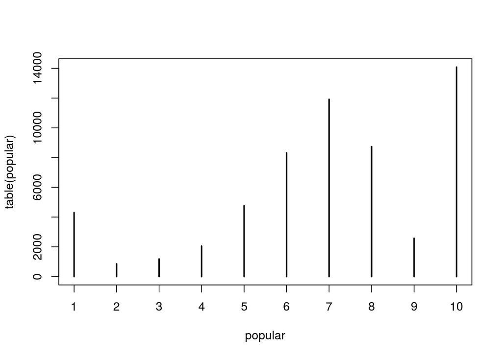

```r
popular = apply(ratings, 1, nnet::which.is.max)
plot(table(popular))
```

Voting patters aren’t uniform as seen by the peaks at 1 and 10.

#### Type Consisteny

When programming, it is helpful if the return value from a function always takes the same form. Not all base R functions follow this practice. For example, the functions `sapply()` and `[.data.frame()` aren’t type-consistent.

```
two_cols = data.frame(x = 1:5, y = letters[1:5])
zero_cols = data.frame()
sapply(two_cols, class)  # a character vector
sapply(zero_cols, class) # a list
two_cols[, 1:2]          # a data.frame
two_cols[, 1]            # an integer vector
```

- `lapply()` and `vapply()` are type consistent.
- `dplyr::select()` and `dplyr::filter()` are also type consistent
- The *purr* package has type-consistent alternatives to base R functions. For example, you can use `map_dbl()` to replace `Map()` and `flatten_df()` to replace `unlist()`.

More Resources: + Use example(functionName) to see examples of a function. + Go to this [link](http://bit.ly/sapplyvlapply) to see how to use sapply and lapply. + Also this [link](http://bit.ly/introapplyR) by Neil Saunders for an overview of the functions.

```r
i39 <- sapply(3:9, seq) # list of vectors
sapply(i39, fivenum)
```

```
##      [,1] [,2] [,3] [,4] [,5] [,6] [,7]
## [1,]  1.0  1.0    1  1.0  1.0  1.0    1
## [2,]  1.5  1.5    2  2.0  2.5  2.5    3
## [3,]  2.0  2.5    3  3.5  4.0  4.5    5
## [4,]  2.5  3.5    4  5.0  5.5  6.5    7
## [5,]  3.0  4.0    5  6.0  7.0  8.0    9
```

```r
vapply(i39, fivenum,
       c(Min. = 0, "1st Qu." = 0, Median = 0, "3rd Qu." = 0, Max. = 0))
```

```
##         [,1] [,2] [,3] [,4] [,5] [,6] [,7]
## Min.     1.0  1.0    1  1.0  1.0  1.0    1
## 1st Qu.  1.5  1.5    2  2.0  2.5  2.5    3
## Median   2.0  2.5    3  3.5  4.0  4.5    5
## 3rd Qu.  2.5  3.5    4  5.0  5.5  6.5    7
## Max.     3.0  4.0    5  6.0  7.0  8.0    9
```

#### Caching Variables

Basically, save variables that you will use frequently!

For example, suppose we wish to normalize each column of a matrix. However, instead of usin the standard deviation of each column, we will use the standard deiation of the entire dataset:

```
apply(x, 2, function(i) mean(i) / sd(x))
```

This is inefficient because the value of `sd(x)` is constant, so recalculating the standard deviation for every column is unnecessary. Instead, we should evaluate once and store the result:

```
sd_x = sd(x)
apply(x, 2, function(i) mean(i) / sd_x)
```

If we compare the two methods on a 100 row by 1,000 column matrix, the cached version is around 100 times faster.

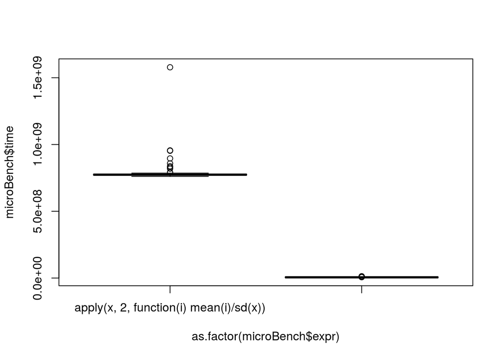

```r
# library(benchmarkme)
# x = matrix(runif(100*1000), nrow = 100, ncol = 1000)
# sd_x = sd(x)
# microBench = microbenchmark(apply(x, 2, function(i) mean(i) / sd(x)),
#                apply(x, 2, function(i) mean(i) / sd_x))
# saveRDS(microBench, "microBench.Rda")
microBench = readRDS("microBench.Rda")

plot(microBench$time ~ as.factor(microBench$expr))
```

Holy hell, do you see the difference in time the code takes to complete by simply creating sd_x?

#### library(memoise)

A more advanced form of caching is to use the *memoise* package. If a function is called multiple times with the same input, it may be possible to speed things up by keeping a cache of known answers that it can retrieve. The *memoise* package allows us to easily store the value of a function call and returns the cached result when the function is called again with the same arguments. This package trades off memory versus speed, since the memoised function stores all previous inputs and outputs. To cache a function, we simply pass the function to the *memoise* function.

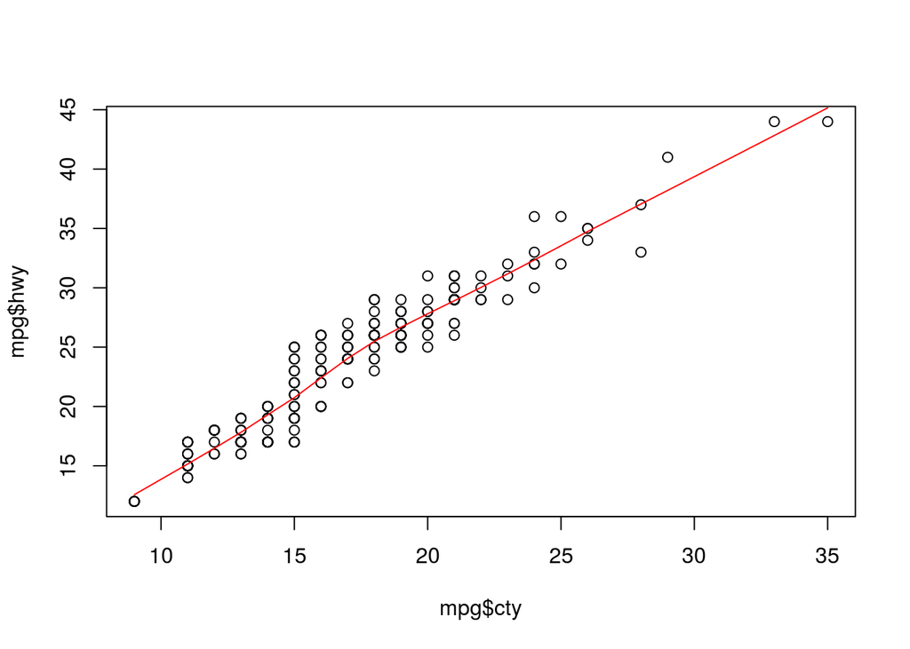

```
## Unit: milliseconds
##            expr       min        lq      mean     median        uq
##  m_plot_mpg(10)  0.101765  0.166813  1.493877  0.2053135  0.238806
##    plot_mpg(10) 71.892954 72.523780 73.325573 72.6746390 74.688531
##       max neval
##  13.23682    10
##  75.81097    10
```

```r
?memoise::memoise

## Description
#mf <- memoise(f) creates mf, a memoised copy of f. A memoised copy is basically a lazier version of the
#same function: it saves the answers of new invocations, and re-uses the answers of old ones. Under the
#right circumstances, this can provide a very nice speedup indeed.

# Argument indicates row to remove
plot_mpg = function(row_to_remove) {
     data(mpg, package = "ggplot2")
     mpg = mpg[-row_to_remove, ]
     plot(mpg$cty, mpg$hwy)
     lines(lowess(mpg$cty, mpg$hwy), col = 2)
}

m_plot_mpg = memoise::memoise(plot_mpg)

microbenchmark(times = 10, unit = "ms", m_plot_mpg(10), plot_mpg(10))
```

#### Function Closures

A closure is an R object that contains functions bound to the environment the closure was created in. Technically, all functions in R have this property, but we use the term *function closure* to denote functions where the environment is not in */GlobalEnv*. One of the environments associated with a function is known as the enclosing environment; that is, where the function was created. This allows us to store alues between function calls. Suppose we want to create a stopwatch type function. This is easily achieved with a function closure:

```r
# <<- assigns values to the parent environment
stop_watch = function() {
     start_time = NULL
     start = function() start_time <<- Sys.time()
     stop = function() {
          stop_time = Sys.time()
          difftime(stop_time, start_time)
     }
     list(start = start, stop = stop)
}
```

The object `watch` is a list that contains two functions. One function for starting the timer and the other for stopping the timer.

```r
watch = stop_watch()
watch$start()
watch$stop()
```

```
## Time difference of 0.0008401871 secs
```

#### The Byte Compiler

The *compiler* package allows R functions to be compiler, resulting in a byte code version that may run faster. The compilation process eliminates a number of costly operations the interpreter has to perform, such as variable lookup.

Since R 2.14.0, all of the standard functions and packages in base R are precompiled into byte code. This is illustrated by the base function `mean()`.

```r
getFunction("mean")
```

```
## function (x, ...)
## UseMethod("mean")
## <bytecode: 0x2ead1f8>
## <environment: namespace:base>
```

The third line contains `bytecode` of the function. This means that the *compiler* package has translated the R function into another language that can be interpreted by a very fast interpreter. Amazingly, the *compiler* package is almost entirely pure R, with just a few C support routines.

Example: The Mean Function

The *compiler* package comes with R, so we just need to load the package in the usual way:

```r
library("compiler")
```

Next, we create an inefficient function for calculating the mean. This function takes in a vector, calculates the length, and then updates the `m` variable.

```r
mean_r = function(x) {
     m = 0
     n = length(x)
     for(i in seq_len(n)) {
          m = m + x[i] / n
     }
     m
}

mean_r(1:10)
```

```
## [1] 5.5
```

This is clearly a bad function and we should just use the mean() function, but it’s a useful comparison. Compiling the function is straightforward:

```r
library(compiler)
cmp_mean_r = cmpfun(mean_r)
```

Then we use the `microbenchmark()` function to compare the three variants:

```r
# Generate some data
x = rnorm(1000)
microbenchmark(times = 10, unit = "ms",
               mean_r(x), cmp_mean_r(x), mean(x))
```

```
## Unit: milliseconds
##           expr      min       lq      mean    median       uq      max
##      mean_r(x) 0.496088 0.497714 0.5692829 0.5222260 0.542650 1.024678
##  cmp_mean_r(x) 0.061670 0.062422 0.0640379 0.0631225 0.064311 0.072577
##        mean(x) 0.005750 0.006886 0.0097688 0.0085465 0.011135 0.021082
##  neval
##     10
##     10
##     10
```

```r
# The native mean() function s faster but check out the compiled version, it's waaay faster than the orginial.
```

#### Compiling Code

The easiest way to compile is to use `cmpfun()`, but that doesn’t scale. If you create a pckage, you can automatically compile the package on installation by adding ByteCompile: true in the DESCRIPTION file.

Most R packages installed using install.packages() are not compiled. We can enable (or force) packages to be compiled by starting R with the environment variable R_COMPILE_PKGS set to a positive integer value and specify that we install the package from source:

```
## Windows users will need Rtools
install.packages("ggplot2", type = "source")
```

Or, if we want to avoid altering the *.Renviron* file, we can specify an additonal argument:

```
install.packages("ggplot2", type = "source", INSTALL_opts = "--byte-compile")
```

A final option is to use just-in-time (JIT) compilation. The `enableJIT()` function disables JIT compilation if the argument is 0. Arguments 1, 2, or 3 implement different levels of optimization. JIT can also be enabled by setting the environment variable R_ENABLE_JIT to one of these values. It is recommended by the book to set the compile level to the maximum value of 3.